# Ch02 2-3-4 Loading Data

Bruce Hartman

University of St. Francis

2026-10-14 Revised 2026-10-22T08:31:57

Abstract

We follow Section 2.3.4 and 2.3.5 of the book using new `tidyverse` methods.

# Introduction

We follow ISLR (2013) pages 48 to 51 for loading data using `tidyverse` concepts.

# Packages

As usual, we have some standard packages.

```
library(ISLR2) # some data files
library(mbadtools)
```

# Data

The `Auto` dataset is in the `ISLR2` package. We discuss reading Excel and csv files in other notebooks.

```
data(Auto)
```

Display the data by yelling its name.

```
Auto
```

|  | mpg | cylinders | displacement | horsepower | weight | acceleration | year | origin | name |
| --- | --- | --- | --- | --- | --- | --- | --- | --- | --- |
| 1 | 18.0 | 8 | 307.0 | 130 | 3504 | 12.0 | 70 | 1 | chevrolet chevelle malibu |
| 2 | 15.0 | 8 | 350.0 | 165 | 3693 | 11.5 | 70 | 1 | buick skylark 320 |
| 3 | 18.0 | 8 | 318.0 | 150 | 3436 | 11.0 | 70 | 1 | plymouth satellite |
| 4 | 16.0 | 8 | 304.0 | 150 | 3433 | 12.0 | 70 | 1 | amc rebel sst |
| 5 | 17.0 | 8 | 302.0 | 140 | 3449 | 10.5 | 70 | 1 | ford torino |
| 6 | 15.0 | 8 | 429.0 | 198 | 4341 | 10.0 | 70 | 1 | ford galaxie 500 |
| 7 | 14.0 | 8 | 454.0 | 220 | 4354 | 9.0 | 70 | 1 | chevrolet impala |
| 8 | 14.0 | 8 | 440.0 | 215 | 4312 | 8.5 | 70 | 1 | plymouth fury iii |
| 9 | 14.0 | 8 | 455.0 | 225 | 4425 | 10.0 | 70 | 1 | pontiac catalina |
| 10 | 15.0 | 8 | 390.0 | 190 | 3850 | 8.5 | 70 | 1 | amc ambassador dpl |

[output cut: 382 more lines]

Summarize data easily:

```
Auto %>% skim
```

```
── Data Summary ────────────────────────
                           Values
Name                       Piped data
Number of rows             392
Number of columns          9
_______________________
Column type frequency:
  factor                   1
  numeric                  8
________________________
Group variables            None
```

|  | skim_variable | n_missing | complete_rate | ordered | n_unique | top_counts |
| --- | --- | --- | --- | --- | --- | --- |
| 1 | name | 0 | 1 | FALSE | 301 | amc: 5, for: 5, toy: 5, amc: 4 |

|  | skim_variable | n_missing | complete_rate | mean | sd | p0 | p25 | p50 | p75 | p100 | hist |
| --- | --- | --- | --- | --- | --- | --- | --- | --- | --- | --- | --- |
| 1 | mpg | 0 | 1 | 23.445918 | 7.8050075 | 9 | 17.000 | 22.75 | 29.000 | 46.6 | ▆▇▆▃▁ |
| 2 | cylinders | 0 | 1 | 5.471939 | 1.7057832 | 3 | 4.000 | 4.00 | 8.000 | 8.0 | ▇▁▃▁▅ |
| 3 | displacement | 0 | 1 | 194.411990 | 104.6440039 | 68 | 105.000 | 151.00 | 275.750 | 455.0 | ▇▂▂▃▁ |
| 4 | horsepower | 0 | 1 | 104.469388 | 38.4911599 | 46 | 75.000 | 93.50 | 126.000 | 230.0 | ▆▇▃▁▁ |
| 5 | weight | 0 | 1 | 2977.584184 | 849.4025600 | 1613 | 2225.250 | 2803.50 | 3614.750 | 5140.0 | ▇▇▅▅▂ |
| 6 | acceleration | 0 | 1 | 15.541327 | 2.7588641 | 8 | 13.775 | 15.50 | 17.025 | 24.8 | ▁▆▇▂▁ |
| 7 | year | 0 | 1 | 75.979592 | 3.6837365 | 70 | 73.000 | 76.00 | 79.000 | 82.0 | ▇▆▇▆▇ |
| 8 | origin | 0 | 1 | 1.576531 | 0.8055182 | 1 | 1.000 | 1.00 | 2.000 | 3.0 | ▇▁▂▁▂ |

There is no missing data in this dataset. but if some entries were missing, we could remove those rows with the `na.omit` function.

Column names can be retrieved like this:

```
colnames(Auto)
```

```
[1] "mpg"          "cylinders"    "displacement" "horsepower"   "weight"
[6] "acceleration" "year"         "origin"       "name"
```

# Graphical and Numeric Summaries

Scatterplots are easily done with `ggplot`. *We no longer use the `attach` function as it always led to trouble.*

```
Auto %>% ggplot() +
  geom_point(aes(cylinders, mpg))
```

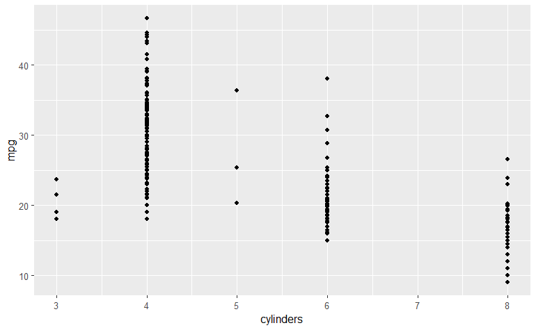

Boxplots are also easy for categorical variables like `cylinders`. The `labs()` function adds titles, subtitles, x and y axis labels.

```
Auto %>% ggplot() +
  geom_boxplot(aes(as.factor(cylinders), mpg), color="red") +
  labs(x="Cylinders",
       y="MPG")
```

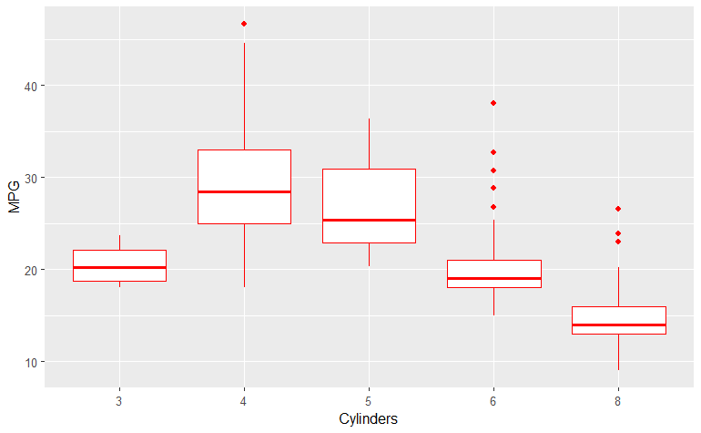

# Histograms

In histograms I like to outline the bars in black, and make the fill the color I want. I can use the alpha parameter to change the transparency. The info message can be suppressed by picking a bins number in the function, or simply using ‘message=FALSE’ in the {r}.

```
Auto %>% ggplot() +
  geom_histogram(aes(mpg), color="black", fill="red", alpha=0.5) +
  labs(x="MPG",
       y="Count")
```

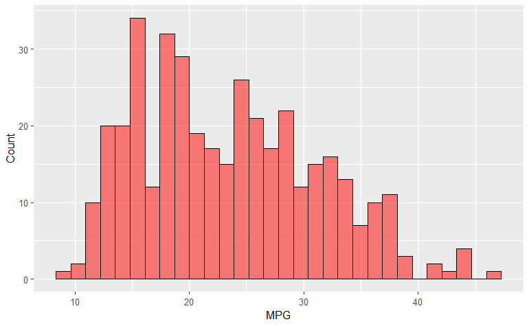

# Pairs plot

The `ggplot` version also shows correlation coefficients and density plots. There are many options; see [GGally::ggpairs](https://www.rdocumentation.org/packages/GGally/topics/ggpairs).

```
Auto %>%
  select(mpg, displacement, horsepower, weight, acceleration) %>%
  ggpairs(progress=F)
```

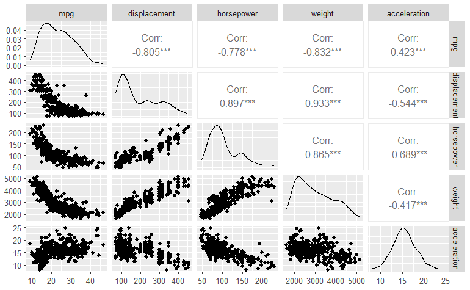

# Summary

The `summary` function still works and is quick, but the `skim` function is better. That’s because you can actually grab the individual numbers out of the `skim` objects.

```
Auto %>% summary()
```

```
      mpg          cylinders      displacement     horsepower        weight
 Min.   : 9.00   Min.   :3.000   Min.   : 68.0   Min.   : 46.0   Min.   :1613
 1st Qu.:17.00   1st Qu.:4.000   1st Qu.:105.0   1st Qu.: 75.0   1st Qu.:2225
 Median :22.75   Median :4.000   Median :151.0   Median : 93.5   Median :2804
 Mean   :23.45   Mean   :5.472   Mean   :194.4   Mean   :104.5   Mean   :2978
 3rd Qu.:29.00   3rd Qu.:8.000   3rd Qu.:275.8   3rd Qu.:126.0   3rd Qu.:3615
 Max.   :46.60   Max.   :8.000   Max.   :455.0   Max.   :230.0   Max.   :5140

  acceleration        year           origin                      name
 Min.   : 8.00   Min.   :70.00   Min.   :1.000   amc matador       :  5
 1st Qu.:13.78   1st Qu.:73.00   1st Qu.:1.000   ford pinto        :  5
 Median :15.50   Median :76.00   Median :1.000   toyota corolla    :  5
 Mean   :15.54   Mean   :75.98   Mean   :1.577   amc gremlin       :  4
 3rd Qu.:17.02   3rd Qu.:79.00   3rd Qu.:2.000   amc hornet        :  4
 Max.   :24.80   Max.   :82.00   Max.   :3.000   chevrolet chevette:  4
                                                 (Other)           :365
```

```
Auto %>% skim()
```

```
── Data Summary ────────────────────────
                           Values
Name                       Piped data
Number of rows             392
Number of columns          9
_______________________
Column type frequency:
  factor                   1
  numeric                  8
________________________
Group variables            None
```

|  | skim_variable | n_missing | complete_rate | ordered | n_unique | top_counts |
| --- | --- | --- | --- | --- | --- | --- |
| 1 | name | 0 | 1 | FALSE | 301 | amc: 5, for: 5, toy: 5, amc: 4 |

|  | skim_variable | n_missing | complete_rate | mean | sd | p0 | p25 | p50 | p75 | p100 | hist |
| --- | --- | --- | --- | --- | --- | --- | --- | --- | --- | --- | --- |
| 1 | mpg | 0 | 1 | 23.445918 | 7.8050075 | 9 | 17.000 | 22.75 | 29.000 | 46.6 | ▆▇▆▃▁ |
| 2 | cylinders | 0 | 1 | 5.471939 | 1.7057832 | 3 | 4.000 | 4.00 | 8.000 | 8.0 | ▇▁▃▁▅ |
| 3 | displacement | 0 | 1 | 194.411990 | 104.6440039 | 68 | 105.000 | 151.00 | 275.750 | 455.0 | ▇▂▂▃▁ |
| 4 | horsepower | 0 | 1 | 104.469388 | 38.4911599 | 46 | 75.000 | 93.50 | 126.000 | 230.0 | ▆▇▃▁▁ |
| 5 | weight | 0 | 1 | 2977.584184 | 849.4025600 | 1613 | 2225.250 | 2803.50 | 3614.750 | 5140.0 | ▇▇▅▅▂ |
| 6 | acceleration | 0 | 1 | 15.541327 | 2.7588641 | 8 | 13.775 | 15.50 | 17.025 | 24.8 | ▁▆▇▂▁ |
| 7 | year | 0 | 1 | 75.979592 | 3.6837365 | 70 | 73.000 | 76.00 | 79.000 | 82.0 | ▇▆▇▆▇ |
| 8 | origin | 0 | 1 | 1.576531 | 0.8055182 | 1 | 1.000 | 1.00 | 2.000 | 3.0 | ▇▁▂▁▂ |

If you want the median of `mpg` for instance, you can grab it from the `skim` output. Median is the 50th percentile.

```
Auto %>% skim %>% select(skim_variable, numeric.p50) %>%
  filter(skim_variable=="mpg")
```

| skim_variable | numeric.p50 |
| --- | --- |
| mpg | 22.75 |

# Conclusion

We found out how do things in sections 2.3.4 and 2.3.5 the modern tidyverse way.

# References

1. ISLR (2013), Chapter 2 Statistical Learning, page 48-51.